# Homework 1

Author

Arinanna Sakoutis

Professional wrestling, while not everyone’s cup of tea, is big business. What started as a carnival act has turned into a global entertainment industry. Netflix recently started showing Monday Night Raw, a program from the biggest North American wrestling company, WWE – this deal is reportedly worth $5 billion. Like any large entity, WWE is not without competition, drama, and scandal.

## General Tips

This is very much a step-by-step process. Don’t go crazy trying to get everything done with as few lines as possible. Read the documentation for the AlphaVantage api! Carefully explore the pages from cagematch. There isn’t a need to get too fancy with anything here – just go with simple function and all should be good. Don’t print comments, but use normal text for explanations.

## Step 1

In the `calls` folder, you’ll find 4 text files – these are transcripts from quarterly earnings calls. Read those files in (glob.glob will be very helpful here), with appropriate column names for ticker, quarter, and year columns; this should be done within a single function. Perform any data cleaning that you find necessary.

```python
import glob as glob
import pandas as pd

file_names = glob.glob("/Users/ariannasakoutis/Desktop/unstructured_notes/*.txt")
```

Here I am just checking to make sure the file names are correct.

```python
file_names[0]
```

```
'/Users/ariannasakoutis/Desktop/unstructured_notes/wwe_q1_2023.txt'
```

Next, I am going to read in the first file to see what it looks like. You’ll notice that I will make a data frame for each file and then combine them all into one data frame.

```python
import re

data_frames = []

for file in file_names:
  df = pd.read_table(file, header = None)
  df['Ticker']=re.search('(?<=notes/)[a-z]{3}(?=_)', file).group(0)
  df['Quarter']=re.search('q[1-4]',file).group(0)
  df['Year']=re.search('[0-9]{4}', file).group(0)
  data_frames.append(df)


calls_data = pd.concat(data_frames)
```

Making sure the Ticker column is all uppercase. Not super important, but I think it looks better that way.

```python
calls_data['Ticker'] = calls_data['Ticker'].str.upper()
print(calls_data)
```

```
                                                     0 Ticker Quarter  Year
0                                 Company Participants    WWE      q1  2023
1                             Seth Zaslow - Head of IR    WWE      q1  2023
2                                      Nick Khan - CEO    WWE      q1  2023
3                                  Frank Riddick - CFO    WWE      q1  2023
4                Paul Levesque - Chief Content Officer    WWE      q1  2023
..                                                 ...    ...     ...   ...
134  So in reverse order, ad share deal with Twitch...    WWE      q2  2023
135                                        Seth Zaslow    WWE      q2  2023
136  Well, thank you, everyone, for joining us on t...    WWE      q2  2023
137                                           Operator    WWE      q2  2023
138  This concludes today's call. Thank you again f...    WWE      q2  2023

[705 rows x 4 columns]
```

The data is now clean and in the proper format

## Step 2

Use the AlphaVantage api to get daily stock prices for WWE and related tickers for the last 5 years – pay attention to your data. You cannot use any AlphaVantage packages (i.e., you can only use requests to grab the data). Tell me about the general trend that you are seeing. I don’t care which viz package you use, but plotly is solid and plotnine is good for ggplot2 users.

In these next lines of code, I am going to get the stock prices for WWE and TKO. Following that, I will plot the stock prices for WWE.

```python
import requests
import pandas as pd
from plotnine import ggplot, aes, geom_line, labs, theme_minimal
from IPython.display import display
```

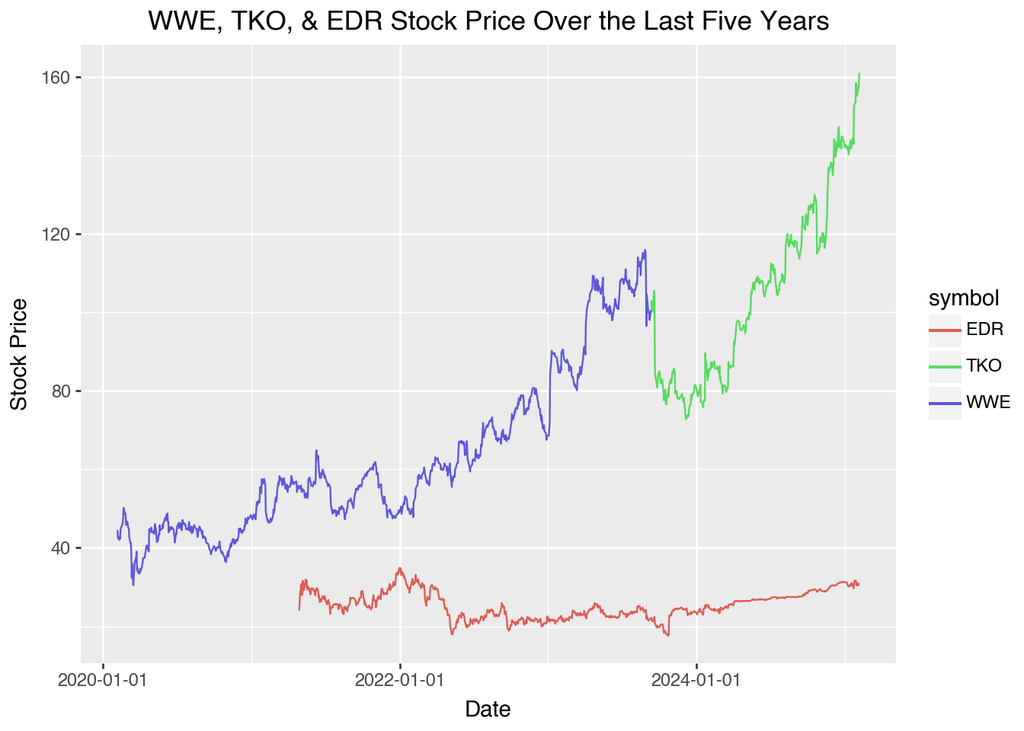

```python
# API Key and stock symbols definition
api_key = "MNM56ZOAR5P2VZ7T"
stocks = ["WWE", "TKO", "EDR"]

# Initialize an empty DataFrame to store results
all_stock_data = pd.DataFrame()

# Fetch stock data for each symbol
for symbol in stocks:
    url = f"https://www.alphavantage.co/query?function=TIME_SERIES_DAILY&symbol={symbol}&outputsize=full&apikey={api_key}"
    response = requests.get(url)
    data = response.json()

    # Retrieve time series data
    time_series = data.get("Time Series (Daily)", {})
    meta = data.get("Meta Data", {})

    # Convert to DataFrame and process
    df = pd.DataFrame.from_dict(time_series, orient="index")
    df["symbol"] = meta.get("2. Symbol", symbol)

    # Rename columns and format
    df.reset_index(inplace=True)
    df.rename(columns={"index": "date", "4. close": "close"}, inplace=True)
    df["close"] = pd.to_numeric(df["close"], errors='coerce')

    # Append to the main DataFrame
    all_stock_data = pd.concat([all_stock_data, df], ignore_index=True)

# Convert date column to datetime
all_stock_data["date"] = pd.to_datetime(all_stock_data["date"])

# Filter data for the past five years
cutoff_date = pd.Timestamp.now() - pd.DateOffset(years=5)
recent_data = all_stock_data[all_stock_data["date"] > cutoff_date]

# Generate stock price trend plot
stock_plot = (
    ggplot(recent_data, aes(x="date", y="close", color="symbol"))
    + geom_line()
    + labs(title="WWE, TKO, & EDR Stock Price Over the Last Five Years", x="Date", y="Stock Price")
)

display(stock_plot)
```

I thought about adding an additional stock to the list of stocks to analyze. I chose Prime drinks because it is the largest deal that WWE has ever struck with a sponsor PRME = pull(“PRME”) Prime Drink is a privately held company and is not publicly traded on the NYSE or any other stock exchange, so did not include it in the analysis.

I chose to use plotnine to plot the stock prices for WWE. I think it is a good package to use because it is similar to ggplot2 in R. As you can see in the plot above, the stock prices for WWE have been on a general upward trend over the last 5 years. There are some dips in the stock prices, but overall, the stock prices have been increasing.

## Step 3

Just like every other nerdy hobby, professional wrestling draws dedicated fans. Wrestling fans often go to cagematch.net to leave reviews for matches, shows, and wrestlers. The following link contains the top 100 matches on cagematch: https://www.cagematch.net/?id=111&view=statistics

The following questions are provided along with the asnwers

- What is the correlation between WON ratings and cagematch ratings?: .31

** Which wrestler has the most matches in the top 100?: Kenny Omega

*** Which promotion has the most matches in the top 100?: New Japan Pro Wrestling

**** What is each promotion’s average WON rating?: shown in code below with mean WON ratings for each promotion

***** Select any single match and get the comments and ratings for that match into a data frame.: shown in code below

Step 3 part A:

First, I will be scraping the data from the website.

```python
from bs4 import BeautifulSoup
import requests

# Define the URL to scrape statistics data from
link = ("https://www.cagematch.net/?id=111&view=statistics")

# Send a GET request to the URL and store the response in 'page'
page = requests.get(link)

#Parse the HTML content of the fetched page using BeautifulSoup with Python's built-in HTML parser
parser = BeautifulSoup(page.content, "html.parser")

#Select all table row ('tr') elements from the parsed HTML.
# The slicing [1:101] is used to skip the header row and select the first 100 data rows.
matches = parser.select('tr')[1:101]

# Initialize an empty list to store match data dictionaries
match_df = []

# Loop through each match (each table row) in the selected rows
for match in matches:
  cols = match.select('td')
# Create a dictionary to hold the extracted data for each match
  match_data = {
    'rank': cols[0].text.strip(),
    'date': cols[1].text.strip(),
    'promotion': cols[2].find('img')['title'].strip(),
    'match': cols[3].text.strip(),
    'WON rating': cols[4].text.strip(),
    'match type': cols[5].text.strip(),
    'rating': cols[6].text.strip(),
    'votes': cols[7].text.strip()
  }
# Append the dictionary to the match_df list
  match_df.append(match_data)

# Convert the list of match dictionaries into a pandas DataFrame for structured data handling
final_df = pd.DataFrame(match_df)

print(final_df)
```

```
   rank        date                promotion  \
0     1  04.01.2017  New Japan Pro Wrestling
1     2  01.03.2003       Pro Wrestling NOAH
2     3  09.04.2017  New Japan Pro Wrestling
3     4  04.01.2023  New Japan Pro Wrestling
4     5  09.06.2018  New Japan Pro Wrestling
..  ...         ...                      ...
95   96  15.07.2023      All Elite Wrestling
96   97  03.09.1994  All Japan Pro Wrestling
97   98  31.03.2006            Ring Of Honor
98   99  03.03.2024      All Elite Wrestling
99  100  04.01.2019  New Japan Pro Wrestling

                                                match WON rating  \
0                     Kazuchika Okada vs. Kenny Omega     ******
```

[output cut: 25 more lines]

Here, I will be converting the WON ratings to a numeric value.

Following that, I will be converting the ratings to a numeric value.

```python
# Function to convert WON ratings to numeric values
def convert_won_to_numeric(won_rating):
    # Remove any non-star characters (e.g., fractions like "1/4")
    stars = won_rating.replace('1/4', '').replace('1/2', '').replace('3/4', '')
    # Count the number of stars
    star_count = len(stars)
    # Handle fractions (e.g., "****1/4" → 4.25)
    if '1/4' in won_rating:
        star_count += 0.25
    elif '1/2' in won_rating:
        star_count += 0.5
    elif '3/4' in won_rating:
        star_count += 0.75
    return star_count
```

```python
import re
def convert(won_rating):
    # Remove surrounding whitespace
    won_rating = won_rating.strip()
    # Use regex to capture a series of asterisks and an optional fraction at the end
    pattern = r"^(\*+)(1/4|1/2|3/4)?$"
    m = re.match(pattern, won_rating)
    if m:
        base = len(m.group(1))
        fraction = m.group(2)
        if fraction == '1/4':
            return base + 0.25
        elif fraction == '1/2':
            return base + 0.5
        elif fraction == '3/4':
            return base + 0.75
        else:
            return base
    else:
        # If the pattern doesn't match, return None (or a default value)
        return None
```

And next, I will be finding the correlation between the two ratings.

```python
final_df['WON Numeric'] = final_df['WON rating'].apply(convert)
print(final_df[['WON rating', 'WON Numeric']].head())
correlation = final_df['WON Numeric'].corr(final_df['rating'])
print(correlation)
```

```
  WON rating  WON Numeric
0     ******         6.00
1      *****         5.00
2      *****         5.00
3  ******1/4         6.25
4    *******         7.00
0.3142055145382091
```

Step 3 part B: Which wrestler has the most matches in the top 100?

```python
#So this goes into the fixture, drops nas, splits them, counts all individual names, counts them and returns the values

# Extract the 'match' column from the dataset, ensuring no missing values.
most_common_wrestler_top_100 = (
    final_df['match']
    .dropna() # Drop any NaN values to avoid errors
    .str.split(r' vs\. | & ')  # Split match strings on 'vs.' or '&' to get individual wrestler names
    .explode() # Flatten the list so that each wrestler appears as a separate row
    .str.strip() # Remove any leading or trailing whitespace from wrestler names
    .value_counts() # Count occurrences of each wrestler's name
    .idxmax() # Retrieve the name of the wrestler with the highest count
)

# Count how many times the most common wrestler appears in the dataset
match_count_of_wrestlers = final_df['match'].str.contains(most_common_wrestler_top_100).sum()
# Print the result
print(f"The wrestler with the most matches in the dataset is: {most_common_wrestler_top_100} with {match_count_of_wrestlers} matches.")
```

```
The wrestler with the most matches in the dataset is: Kenny Omega with 16 matches.
```

Step 3 part C: What is the promotion with the most matches in the top 100?

```python
from collections import Counter # Import Counter for counting occurrences

# Finding the promotion that appears the most times in the dataset
most_of_promotion_counts = (
    final_df['promotion']
    .value_counts()
    .idxmax() # Get the promotion with the highest count
)


# Count the number of matches for each promotion
promotion_counts = final_df['promotion'].str.contains(most_of_promotion_counts).sum()


print(f"The promotion with the most matches in the top 100 is: {most_of_promotion_counts} (appearing in {promotion_counts} matches)")
```

```
The promotion with the most matches in the top 100 is: New Japan Pro Wrestling (appearing in 35 matches)
```

Step 3 part D: What is each promotion’s average WON rating?

```python
# Group by the 'promotion' column and calculate the mean WON rating for each promotion.
promotion_avg_won = final_df.groupby('promotion')['WON Numeric'].mean()

# Print the average WON rating for each promotion.
print("Average WON rating by promotion:")
print(promotion_avg_won)
```

```
Average WON rating by promotion:
promotion
All Elite Wrestling                     5.562500
All Japan Pro Wrestling                 4.979167
All Japan Women's Pro-Wrestling         4.916667
DDT Pro Wrestling                            NaN
GAEA Japan                                   NaN
JTO                                     4.750000
Japanese Women Pro-Wrestling Project    5.000000
Lucha Underground                            NaN
New Japan Pro Wrestling                 5.392857
Pro Wrestling NOAH                      4.791667
Ring Of Honor                           4.928571
Total Nonstop Action Wrestling          5.000000
World Championship Wrestling            5.000000
World Wonder Ring Stardom               5.500000
World Wrestling Entertainment           4.892857
Name: WON Numeric, dtype: float64
```

Step 3 part E: Select any single match and get the comments and ratings for that match into a data frame.

```python
#https://www.cagematch.net/?id=111&view=comments

#https://www.cagematch.net/?id=111&nr=8034&page=99

#https://www.cagematch.net/?id=111&nr=2510&page=99
```

The last link above is the link to the match that I will be using to get the comments and ratings for the match.

Ex comment: “this match is the best thing i have ever seen in my life. i watched it about 3 days ago but im still in shock”

Next, I am going to be turning this into a dataframe.

```python
import requests
from bs4 import BeautifulSoup
import pandas as pd

link = ("https://www.cagematch.net/?id=111&nr=2510&page=99")


page1 = requests.get(link)

parser1 = BeautifulSoup(page1.content, "html.parser")


matches = parser1.select('.Comment')


data = []
# Loop over each element found in the 'matches' list.
for m_data in matches:
# Within each comment block, look for a <div> element that has the class 'CommentContents'.
    comment_el = m_data.find('div', class_='CommentContents')
    if comment_el:
        comment = comment_el.get_text(strip=True)

        match = re.search(r'\[(\d+\.\d+)\]', comment)

        if match:
          comment = re.sub(r'\[(\d+\.\d+)\]', '', comment)
          data.append({'CommentContents': comment, 'Rating': match.group(1)})
        else:
          data.append({'CommentContents': comment, 'Rating': None})
# If no rating is found in the comment, append the comment with a 'None' value for the rating.
df = pd.DataFrame(data)

print(df)
```

```
                                       CommentContents Rating
0     "this match is the best thing i have ever see...   10.0
1     "The Tiger Suplex from the ramp made me see G...   10.0
2     "This was easily in the top 5 matches in wres...   10.0
3     "[****** 3/4 ] for me this fight shouldn't ha...   10.0
4     "Ho visto un match di Kobashi nella mia vita,...   10.0
..                                                 ...    ...
215   "Manche Leute fragen, warum der Observer (von...   10.0
216   "Also was anderes als die Höchstwertung wäre ...   10.0
217   "Man kann es als "Die Schlacht der Puro-Götte...   10.0
218   "Eines der Matches, denen man bedenkenlos ***...   10.0
219   "Grandios geführtes Match zwischen zwei der b...   10.0

[220 rows x 2 columns]
```

In this data frame, I have the comments for the match that I selected. I also have the ratings for the comments. Initially, I did not have a seperate column for the rating, so I used regex to extract the ratings from the comments. I then created a new column for the ratings.

## Step 4

You can’t have matches without wrestlers. The following link contains the top 100 wrestlers, according to cagematch: https://www.cagematch.net/?id=2&view=statistics

*** Of the top 100, who has wrestled the most matches?:

***** Of the top 100, which wrestler has the best win/loss?:

Step 4 part A:

```python
import requests
import re
import pandas as pd
from bs4 import BeautifulSoup

def fetch_top_wrestlers():

    top_wrestler_url = "https://www.cagematch.net/?id=2&view=statistics"
    response = requests.get(top_wrestler_url)
    soup = BeautifulSoup(response.content, "html.parser")

    # Get all <a> tags within table elements
    wrestler_links = soup.select("table a[href]")

    # Only keep links with exactly two '&' characters in the href
    valid_links = [link for link in wrestler_links if link['href'].count('&') == 2]

    wrestlers_list = []
    for link in valid_links:
        name = link.text.strip()
        href = link['href']
        # Use regex to extract the wrestler's ID from the href
        match = re.search(r'nr=(\d+)', href)
        if match:
            wrestler_id = match.group(1)
            wrestlers_list.append({'Name': name, 'ID': wrestler_id})

    return pd.DataFrame(wrestlers_list)

def fetch_wrestler_stats(df_wrestlers):

    match_data = []
    for _, wrestler in df_wrestlers.iterrows():
        wrestler_id = wrestler["ID"]
        name = wrestler["Name"]
        stats_url = f"https://www.cagematch.net/?id=2&nr={wrestler_id}&page=22"
        stats_response = requests.get(stats_url)
        stats_soup = BeautifulSoup(stats_response.content, "html.parser")

        # Locate the statistics box (assumed to be in elements with class 'InformationBoxContents')
        wrestler_stats = stats_soup.select('.InformationBoxContents')

        if wrestler_stats and len(wrestler_stats) >= 4:
            total_matches = wrestler_stats[0].text.strip()
            total_wins = wrestler_stats[1].text.strip()
            # The following values are available if needed:
            # losses = wrestler_stats[2].text.strip()
            # draws  = wrestler_stats[3].text.strip()

            match_data.append({
                "ID": wrestler_id,
                "Name": name,
                "Matches": total_matches,
                "Wins": total_wins
            })
    return pd.DataFrame(match_data)
```

```python
def process_wrestler_stats(df_stats):

    #Remove any non-digit characters from the 'Matches' column and convert to numbers
    df_stats['Matches'] = (
        df_stats['Matches']
        .astype(str)
        .str.replace(r'\D', '', regex=True)
    )
    df_stats['Matches'] = pd.to_numeric(df_stats['Matches'], errors='coerce')

    #Determine the maximum number of matches
    max_matches = df_stats['Matches'].max()
    print("The most number of matches: ", max_matches)

    # Extract a numeric wins count from the 'Wins' column
    df_stats["Wins_count"] = (
        df_stats["Wins"]
        .astype(str)
        .str.extract(r'(\d+)')
        .astype(int)
    )

    #Calculate the win percentage for each wrestler
    df_stats["Win_Percentage"] = df_stats["Wins_count"] / df_stats["Matches"]

    #Remove a specific wrestler if desired
    df_stats = df_stats[df_stats['Name'] != "Gene Okerlund"]

    #(Re)calculate win percentage if needed after filtering
    df_stats["Win_Percentage"] = df_stats["Wins_count"] / df_stats["Matches"]

    #Identify the wrestler with the highest win percentage
    best_index = df_stats["Win_Percentage"].idxmax()
    best_wrestler = df_stats.loc[best_index]

    print("\nBest wrestler by Win Percentage:")
    print(best_wrestler)

    return df_stats
```

```python
def main():
    #Step 1: Fetch the top wrestlers and their IDs
    df_wrestlers = fetch_top_wrestlers()

    #Step 2: For each wrestler, fetch the match statistics
    df_wrestlers_stats = fetch_wrestler_stats(df_wrestlers)
    print("Wrestler Statistics DataFrame:")
    print(df_wrestlers_stats)

    #Step 3: Process the statistics (clean data, compute win percentage, etc.)
    process_wrestler_stats(df_wrestlers_stats)

if __name__ == "__main__":
    main()
```

```
Wrestler Statistics DataFrame:
       ID              Name Matches          Wins
0     360     Kenta Kobashi    2405  1195 (49.7%)
1     541  Mitsuharu Misawa    3557  1937 (54.5%)
2     290   Toshiaki Kawada    3043  1477 (48.5%)
3   10402      Mayu Iwatani    1022   494 (48.3%)
4    2265     Manami Toyota    2740  1616 (59.0%)
..    ...               ...     ...           ...
95   1091         Ric Flair    4999  2553 (51.1%)
96    990      Great Sasuke    2088  1193 (57.1%)
97  20600       Suzu Suzuki     699   357 (51.1%)
98  10904            Sareee     746   320 (42.9%)
99    870        Chris Hero    1825   913 (50.0%)

[100 rows x 4 columns]
The most number of matches:  4999

Best wrestler by Win Percentage:
ID                         1096
Name              Antonio Inoki
Matches                    3688
Wins               2929 (79.4%)
Wins_count                 2929
Win_Percentage         0.794197
Name: 84, dtype: object
```

You’ll notice that although Gene Okerlund had the highest win percentages. It is important to consider the fact that he was actaully an american announcer for WWE and only did promotional fights, with that said, the correct wrestler witht the highest win loss ratio is actually Antonio Inoki.

## Step 5

With all of this work out of the way, we can start getting down to strategy.

First, what talent should WWE pursue? Advise carefully.

Second, reconcile what you found in steps 3 and 4 with Netflix’s relationship with WWE. Use the data from the following page to help make your case: https://wrestlenomics.com/tv-ratings/

The wrestling TV ratings from Wrestlenomics (via wrestlenomics.com/tv-ratings) indicate that viewers—especially those consuming content on streaming platforms like Netflix—are drawn to narratives that combine in-ring excellence with compelling backstories. Insight: The high match counts and win percentages tell one part of the story, but today’s audiences also demand context, drama, and behind-the-scenes insights. Recommendation: WWE should use the legacy of performers with outstanding statistical records (like the storied careers of its veterans) as a narrative foundation for Netflix specials, documentaries. This not only reinforces WWE’s brand credibility but also appeals to a broader, digitally savvy audience.

Netflix’s involvement provides a platform to repackage historical data in a new format. For example, archival footage of legendary wrestlers—highlighting record-setting matches or dramatic win streaks—can be integrated into new programming.

By curating content that juxtaposes historical excellence (as seen in your match and win/loss data) with modern, fast-paced storytelling, WWE can attract both nostalgic longtime fans and new viewers who discover wrestling through streaming.

Third, do you have any further recommendations for WWE?

My further reccomendations wuld be to consider the image and likenes of the wrestlers. Although performance plays a large role in the success of WWE, the image and likeness of the wrestlers is also important because it can draw in more fans, but for sure continue to incorporate analytics into booking decisions.